# R Tutorial at the WZB

January 10, 2019

## Today's schedule

1. Short recap
2. Practical text mining with the `tm` package (II)
3. Document similarity

## Short recap

## Practical text mining with the `tm` package

## The `tm` package

- extensive set of tools for text mining in R
- developed since 2008 by Feinerer et al.

Resources to start:

- [package overview on CRAN](https://cran.r-project.org/web/packages/tm/index.html)
- [Introduction to the tm Package](https://cran.r-project.org/web/packages/tm/vignettes/tm.pdf)

I will demonstrate how to use the package to investigate word frequency and document similarity.

## Creating a corpus

A corpus contains the raw text for each document (identified by a document ID).

The base class is `VCorpus` which can be initialized with a data source.

Read plain text files from a directory:

```r
corpus <- VCorpus(DirSource('path/to/documents', encoding = 'UTF-8'),
                  readerControl = list(language = 'de'))  # default language is 'en'
```

- `encoding` specifies the text format → important for special characters (like German umlauts)
- many file formats supported (Word documents, PDF documents, etc.)

## Creating a corpus

A data frame can be converted to a corpus, too. It must contain at least the columns `doc_id`, `text`:

```r
df_texts
##  doc_id  text                                           date
##  <chr>   <chr>                                          <chr>
## 1 Grüne   "A. EINLEITUNG\nLiebe Bürgerinnen und Bürger,… 2017…
## 2 Linke   "Die Zukunft, für die wir kämpfen: SOZIAL. GE… 2017…
## 3 SPD     "Es ist Zeit für mehr Gerechtigkeit!\n2017 is… 2017…
```

```r
corpus <- VCorpus(DataframeSource(df_texts))
```

## The English Europarl corpus

We load a sample of the [European Parliament Proceedings Parallel Corpus](http://www.statmt.org/europarl/) with English texts. If you want to follow along, download ["08textmining-resource.zip" from the tutorial website](https://wzbsocialsciencecenter.github.io/wzb_r_tutorial/#8---text-mining-i).

```r
library(tm)

europarl <- VCorpus(DirSource('08textmining-resources/nltk_europarl'))
europarl
```

```
## <<VCorpus>>
## Metadata:  corpus specific: 0, document level (indexed): 0
## Content:  documents: 10
```

## Inspecting a corpus

`inspect` returns information on corpora and documents:

```r
inspect(europarl)
```

```
## <<VCorpus>>
## Metadata:  corpus specific: 0, document level (indexed): 0
## Content:  documents: 10
##
## [[1]]
## <<PlainTextDocument>>
## Metadata:  7
## Content:  chars: 145780
##
## [[2]]
## <<PlainTextDocument>>
## Metadata:  7
## Content:  chars: 554441
##
## [[3]]
## <<PlainTextDocument>>
## Metadata:  7
## Content:  chars: 228141
##
## [[4]]
## <<PlainTextDocument>>
## Metadata:  7
## Content:  chars: 559
##
## [[5]]
## <<PlainTextDocument>>
## Metadata:  7
## Content:  chars: 314931
##
## [[6]]
## <<PlainTextDocument>>
## Metadata:  7
## Content:  chars: 147766
##
## [[7]]
## <<PlainTextDocument>>
## Metadata:  7
## Content:  chars: 170580
##
## [[8]]
## <<PlainTextDocument>>
## Metadata:  7
## Content:  chars: 565922
##
## [[9]]
## <<PlainTextDocument>>
## Metadata:  7
## Content:  chars: 539764
##
## [[10]]
## <<PlainTextDocument>>
## Metadata:  7
## Content:  chars: 372125
```

## Inspecting a corpus

Information for the fourth document:

```r
inspect(europarl[[4]])
```

```
## <<PlainTextDocument>>
## Metadata:  7
## Content:  chars: 559
##
##
## Adoption of the Minutes of the previous sitting Mr President , I simply wanted to pass on some news .
## There was a terrorist attack this morning in Madrid .
## Someone planted a car bomb and one person has died .
## On behalf of my Group , I once again condemn these terrorist acts .
## Thank you , Mrs Fraga Estévez .
## We had heard about this regrettable incident .
## Unfortunately , the terrorist murderers are once again punishing Spanish society .
## I note your comments with particular keenness , as you may expect , given that I too am Spanish .
## ( The Minutes were approved )
```

## Inspecting a corpus

Get the raw text of a document with `content()`:

```r
head(content(europarl[[1]]))
```

```
## [1] " "
## [2] "Resumption of the session I declare resumed the session of the European Parliament adjourned on Friday 17 December 1999 , and I would like once again to wish you a happy new year in the hope that you enjoyed a pleasant festive period ."
## [3] "Although , as you will have seen , the dreaded ' millennium bug ' failed to materialise , still the people in a number of countries suffered a series of natural disasters that truly were dreadful ."
## [4] "You have requested a debate on this subject in the course of the next few days , during this part-session ."
## [5] "In the meantime , I should like to observe a minute ' s silence , as a number of Members have requested , on behalf of all the victims concerned , particularly those of the terrible storms , in the various countries of the European Union ."
## [6] "Please rise , then , for this minute ' s silence ."
```

## Text processing

We want to investigate word frequencies in our corpus. To count words, we need to transform raw text into a *normalized* sequence of *tokens*.

Why normalize text? Consider these documents:

1. "We can't explain what we don't know."
2. "We cannot do that. We do not want that."
- instances of *"We"* and *"we"* shouldn't be counted separately → transform to lower case
- instances of contracted and expanded words (*"can't"* and *"cannot"*) shouldn't be counted separately → expand all contractions

## Text processing

Text processing includes many steps and hence many decisions that have **big effect** on your results. Several possibilities will be shown here. If and how to apply them depends heavily on your data and your later analysis.

Can you think of an example, where unconditional lower case transformation is bad?

## Text normalization

Normalization might involve some of the following steps:

- replace contractions (*"shouldn't"* → *"should not"*)
- remove punctuation and special characters
- case conversion (usually to lower case)
- remove stopwords (extremely common words like  
  *"the, a, to, …"*)
- correct spelling
- stemming / lemmatization

**The order is important!**

## Text normalization with `tm`

Text normalization can be employed with "transformations" in `tm`.

Concept:

```
tm_map(<CORPUS>, content_transformer(<FUNCTION>), <OPTIONAL ARGS>)
```

- `<FUNCTION>` can be any function that takes a character vector, transforms it, and returns the result as character vector
- `<OPTIONAL ARGS>` are fixed arguments passed to `<FUNCTION>`
- `tm` comes with many predefined transformation functions like `removeWords`, `removePunctuation`, `stemDocuments`, …

## Text normalization with `tm`

A transformation pipeline applied to our corpus (only showing the first three documents):

Original documents:

```
##   name                                                  text
## 1    1 Resumption of the session I declare resumed the se...
## 2    2 Adoption of the Minutes of the previous sitting Th...
## 3    3 Middle East peace process ( continuation ) The nex...
```

```r
europarl <- tm_map(europarl, content_transformer(textclean::replace_contraction)) %>%
  tm_map(content_transformer(tolower)) %>%
  tm_map(removeNumbers) %>%
  tm_map(removeWords, stopwords('en')) %>%
  tm_map(removePunctuation) %>%
  tm_map(stripWhitespace)
```

After text normalization:

```
##   name                                                  text
## 1    1 resumption session declare resumed session europea...
## 2    2 adoption minutes previous sitting minutes yesterda...
## 3    3 middle east peace process continuation next item c...
```

## Creating a DTM

- `DocumentTermMatrix()` takes a corpus, tokenizes it, generates document term matrix *(DTM)*
- parameter `control`: adjust the transformation from corpus to DTM
  - here: allow words that are at least 2 characters long
  - by default, words with less than 3 characters would be removed

```r
dtm <- DocumentTermMatrix(europarl,
                          control = list(wordLengths = c(2, Inf)))
inspect(dtm)
```

```
## <<DocumentTermMatrix (documents: 10, terms: 14118)>>
## Non-/sparse entries: 42920/98260
## Sparsity           : 70%
## Maximal term length: 24
## Weighting          : term frequency (tf)
## Sample             :
##                 Terms
## Docs             also can commission european  mr must parliament
##   ep-00-01-17.en   82  46        130       93 128   53         79
##   ep-00-01-18.en  306 200        692      477 356  316        258
##   ep-00-01-19.en  132 107        104      187 157   99        104
##   ep-00-01-21.en    0   0          0        0   1    0          0
##   ep-00-02-02.en  188 118        194      298 220  157        191
##   ep-00-02-03.en   69  59         36      146  73   68        101
##   ep-00-02-14.en   80  63        126      132  86   75         91
##   ep-00-02-15.en  312 255        562      449 365  375        216
##   ep-00-02-16.en  293 183        260      556 360  179        212
##   ep-00-02-17.en  185 142        184      336 307  215        116
##                 Terms
## Docs             president union will
##   ep-00-01-17.en        89    56   94
##   ep-00-01-18.en       203   169  575
##   ep-00-01-19.en        89   114  284
##   ep-00-01-21.en         1     0    0
##   ep-00-02-02.en       183   199  297
##   ep-00-02-03.en        47    50  113
##   ep-00-02-14.en        90    61  123
##   ep-00-02-15.en       246   232  565
##   ep-00-02-16.en       187   391  484
##   ep-00-02-17.en       178   156  241
```

## Creating a DTM

- a `tm` DTM is a **sparse matrix** → only values \(\ne 0\) are stored → saves a lot of memory
- many values in a DTM are 0 for natural language texts → can you explain why?
- some functions in R can't work with sparse matrices → convert to an ordinary matrix then:

```r
as.matrix(dtm)[,1:8]   # cast to an ordinary matrix and see first 8 terms
```

```
##                 Terms
## Docs             aan abandon abandoned abandoning abandonment abattoirs
##   ep-00-01-17.en   0       0         0          0           0         0
##   ep-00-01-18.en   0       1         4          0           0         0
##   ep-00-01-19.en   0       1         1          1           0         0
##   ep-00-01-21.en   0       0         0          0           0         0
##   ep-00-02-02.en   0       0         0          0           0         0
##   ep-00-02-03.en   0       1         6          0           0         0
##   ep-00-02-14.en   0       0         1          0           0         0
##   ep-00-02-15.en   1       0         1          0           0         1
##   ep-00-02-16.en   0       0         0          0           0         0
##   ep-00-02-17.en   0       1         6          0           1         0
##                 Terms
## Docs             abb abbalsthom
##   ep-00-01-17.en   0          0
##   ep-00-01-18.en   3          0
##   ep-00-01-19.en   0          0
##   ep-00-01-21.en   0          0
##   ep-00-02-02.en   0          0
##   ep-00-02-03.en   0          0
##   ep-00-02-14.en   0          0
##   ep-00-02-15.en   0          0
##   ep-00-02-16.en   0          0
##   ep-00-02-17.en   0          7
```

## Creating a \(\text{tfidf}\)-weighted DTM

You can create a \(\text{tfidf}\)-weighted matrix by passing `weightTfIdf` as a weighting function:

```r
tfidf_dtm <- DocumentTermMatrix(europarl,
                                control = list(weighting = weightTfIdf))
inspect(tfidf_dtm)
```

```
## <<DocumentTermMatrix (documents: 10, terms: 14058)>>
## Non-/sparse entries: 42518/98062
## Sparsity           : 70%
## Maximal term length: 24
## Weighting          : term frequency - inverse document frequency (normalized) (tf-idf)
## Sample             :
##                 Terms
## Docs                      car    estévez      fraga     incident
##   ep-00-01-17.en 0.000000e+00 0.00000000 0.00000000 0.000000e+00
##   ep-00-01-18.en 8.929568e-05 0.00000000 0.00000000 2.655956e-04
##   ep-00-01-19.en 0.000000e+00 0.00000000 0.00000000 0.000000e+00
##   ep-00-01-21.en 2.083333e-02 0.06920684 0.06920684 2.754017e-02
##   ep-00-02-02.en 4.004806e-05 0.00000000 0.00000000 0.000000e+00
##   ep-00-02-03.en 8.155637e-03 0.00000000 0.00000000 0.000000e+00
##   ep-00-02-14.en 7.293414e-05 0.00000000 0.00000000 0.000000e+00
##   ep-00-02-15.en 0.000000e+00 0.00000000 0.00000000 2.907957e-05
##   ep-00-02-16.en 0.000000e+00 0.00000000 0.00000000 0.000000e+00
##   ep-00-02-17.en 0.000000e+00 0.00000000 0.00000000 2.181760e-04
##                 Terms
## Docs               keenness       madrid    murderers    planted
##   ep-00-01-17.en 0.00000000 0.0000000000 0.000000e+00 0.00000000
##   ep-00-01-18.en 0.00000000 0.0000000000 0.000000e+00 0.00000000
##   ep-00-01-19.en 0.00000000 0.0001884217 0.000000e+00 0.00000000
##   ep-00-01-21.en 0.06920684 0.0361867832 4.837350e-02 0.06920684
##   ep-00-02-02.en 0.00000000 0.0000000000 0.000000e+00 0.00000000
##   ep-00-02-03.en 0.00000000 0.0000000000 0.000000e+00 0.00000000
##   ep-00-02-14.en 0.00000000 0.0000000000 0.000000e+00 0.00000000
##   ep-00-02-15.en 0.00000000 0.0000382095 0.000000e+00 0.00000000
##   ep-00-02-16.en 0.00000000 0.0000000000 0.000000e+00 0.00000000
##   ep-00-02-17.en 0.00000000 0.0000000000 7.664394e-05 0.00000000
##                 Terms
## Docs                punishing    terrorist
##   ep-00-01-17.en 0.0000000000 0.000000e+00
##   ep-00-01-18.en 0.0001036691 0.000000e+00
##   ep-00-01-19.en 0.0000000000 5.423876e-05
##   ep-00-01-21.en 0.0483735020 6.250000e-02
##   ep-00-02-02.en 0.0000000000 4.004806e-05
##   ep-00-02-03.en 0.0000000000 8.495455e-05
##   ep-00-02-14.en 0.0000000000 0.000000e+00
##   ep-00-02-15.en 0.0000000000 0.000000e+00
##   ep-00-02-16.en 0.0000000000 0.000000e+00
##   ep-00-02-17.en 0.0000000000 6.601749e-05
```

## Working with a DTM

`Terms()` returns the vocabulary of a DTM as a character string vector. We can see how many unique words we have:

```r
length(Terms(dtm))
```

```
## [1] 14118
```

```r
range(dtm)
```

```
## [1]   0 692
```

`findFreqTerms()` returns the terms that occur above a certain threshold (here at least 500 occurrences):

```r
findFreqTerms(dtm, 500)
```

```
##  [1] "also"         "can"          "commission"   "commissioner"
##  [5] "committee"    "community"    "council"      "countries"
##  [9] "development"  "europe"       "european"     "fact"
## [13] "first"        "however"      "important"    "just"
## [17] "like"         "made"         "make"         "member"
## [21] "mr"           "must"         "need"         "new"
## [25] "now"          "one"          "parliament"   "people"
## [29] "policy"       "political"    "president"    "question"
## [33] "report"       "rights"       "say"          "social"
## [37] "states"       "support"      "take"         "therefore"
## [41] "time"         "union"        "us"           "way"
## [45] "will"         "within"       "work"
```

## Working with a DTM

`findMostFreqTerms()` returns the \(N\) most frequent terms per document:

```r
findMostFreqTerms(dtm, 5)
```

```
## $`ep-00-01-17.en`
## commission         mr    regions       like     report
##        130        128        103         98         98
##
## $`ep-00-01-18.en`
## commission       will   european         mr       must
##        692        575        477        356        316
##
## $`ep-00-01-19.en`
##     will  council european       mr     also
##      284      218      187      157      132
##
## $`ep-00-01-21.en`
## terrorist   minutes   spanish      acts  adoption
##         3         2         2         1         1
##
## $`ep-00-02-02.en`
##   european       will         mr      union commission
##        298        297        220        199        194
##
## $`ep-00-02-03.en`
##   european       will parliament        car       cars
##        146        113        101         96         93
##
## $`ep-00-02-14.en`
##   european commission       will      areas      urban
##        132        126        123        101         99
##
## $`ep-00-02-15.en`
##       will commission   european       must         mr
##        565        562        449        375        365
##
## $`ep-00-02-16.en`
## european     will    union       mr  council
##      556      484      391      360      325
##
## $`ep-00-02-17.en`
## european       mr     will     must  tourism
##      336      307      241      215      187
```

## Working with a DTM

With a tf-idf weighted DTM, we get a better sense of which terms are central to each document:

```r
findMostFreqTerms(tfidf_dtm, 5)
```

```
## $`ep-00-01-17.en`
##      berend  schroedter        koch  structural         cen
## 0.002601040 0.002506025 0.002095435 0.001830871 0.001800720
##
## $`ep-00-01-18.en`
##      hulten  commission        will    forestry   discharge
## 0.002521388 0.002348167 0.001951150 0.001853961 0.001829658
##
## $`ep-00-01-19.en`
##       tobin      israel     anchovy     israeli        will
## 0.005667232 0.004407847 0.002702659 0.002518770 0.002341426
##
## $`ep-00-01-21.en`
##    estévez      fraga   keenness    planted  terrorist
## 0.06920684 0.06920684 0.06920684 0.06920684 0.06250000
##
## $`ep-00-02-02.en`
## conciliation      altener     european         will         card
##  0.002488211  0.002045752  0.001814054  0.001807966  0.001535279
##
## $`ep-00-02-03.en`
##        cars   recycling         car    vehicles     endlife
## 0.013723371 0.010060176 0.008155637 0.007636659 0.006706784
##
## $`ep-00-02-14.en`
##    interreg      strand       urban       rural         iii
## 0.010768148 0.005757826 0.003715465 0.002476977 0.002121101
##
## $`ep-00-02-15.en`
##       water        will  commission   lienemann   additives
## 0.001954556 0.001889213 0.001879182 0.001685555 0.001604799
##
## $`ep-00-02-16.en`
##      cyprus         acp   macedonia    european     cypriot
## 0.003717818 0.002682789 0.002163648 0.001948263 0.001914479
##
## $`ep-00-02-17.en`
## derivatives       ucits       ejido     tourism      angola
## 0.003508886 0.003508886 0.003179928 0.003176273 0.002835826
```

## Document similarity

## Document similarity and distance

Feature vectors such as word counts per document in a DTM can be used to measure **similarity between documents**.

Imagine we had a very simple corpus with only three documents and two words in the vocabulary:

```
##      hello world
## doc1     2     1
## doc2     3     2
## doc3     0     1
```

→ each document is a two-dimensional feature vector, e.g.:  
\(\text{doc1} = \begin{pmatrix}2 \\ 1 \end{pmatrix}\).

## Document similarity and distance

Since we have two-dimensional feature vectors, we could visualize feature vectors in cartesian space:

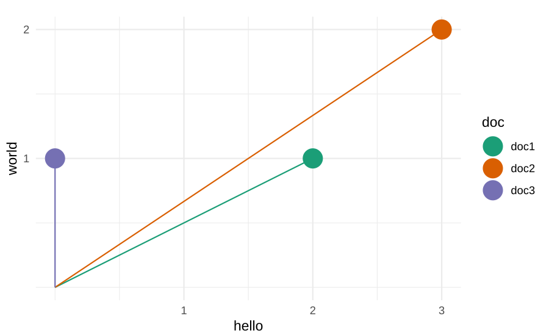

How can we measure how close or far apart these vectors are?

## Document similarity and distance

If normalized to a range of \([0, 1]\), similarity and distance are **complements**. You can then convert between both:

\(\text{distance} = 1 - \text{similarity}\).

A distance of 0 means two vectors are identical (they have maximum similarity of 1).

## Distance measures

We can use **similarity and distance measures** to measure a degree of closeness (or distance) between two feature vectors (i.e. documents).

There are many different measures, but a proper *distance metric* must satisfy the following conditions for distance metric \(d\) and feature vectors \(x, y, z\) ([A. Huang 2008](http://www.academia.edu/download/32952068/pg049_Similarity_Measures_for_Text_Document_Clustering.pdf)):

1. \(d(x, y) \ge 0\): the distance can never be negative.
2. \(d(x, y) = 0\) if and only if \(x = y\): (only) identical vectors have a distance of 0.
3. \(d(x, y) = d(y, x)\): distances are symmetric.
4. \(d(x, z) \le d(x, y) + d(y, z)\): satisfies triangle inequality.

## Euclidian distance

The *Euclidian distance* is the length of the straight line between two points in space.

In 2D, it's an application of the Pythagorean theorem \(c = \sqrt{a^2 + b^2}\). For *doc2* and *doc3* this means: \(\sqrt{(3-0)^2 + (2-1)^2}\).

## Euclidian distance

General formular: \(d(x, y) = \sqrt{\sum_{i=1}^{n}(x_i-y_i)^2}\) for vectors \(x\), \(y\) in \(n\)-dimensional space. This distance is also called the *L2-norm*.

## Euclidian distance

The Euclidian distance satisfies all conditions for distance metrics.

**Beware: The euclidian distance takes the length of the vectors into account (not only their direction!).** → in a DTM, the total count of words determines the distance.

How can you make sure that only the proportion of words is taken into account?

## Euclidian distance

In R, the function `dist` provides several distance measures. The default is the Euclidian distance. The distances between each row are calculated and returned as `dist` type ("triangular matrix"):

```r
dist(docs)
```

```
##          doc1     doc2
## doc2 1.414214
## doc3 2.000000 3.162278
```

Using a normalized DTM:

```r
docs_normed <- docs / rowSums(docs)   # word proportions
dist(docs_normed)
```

```
##           doc1      doc2
## doc2 0.0942809
## doc3 0.9428090 0.8485281
```

You can use `as.matrix()` to convert to a distance to a proper matrix.

## Cosine distance

The cosine distance uses the angle between two vectors as distance metric:

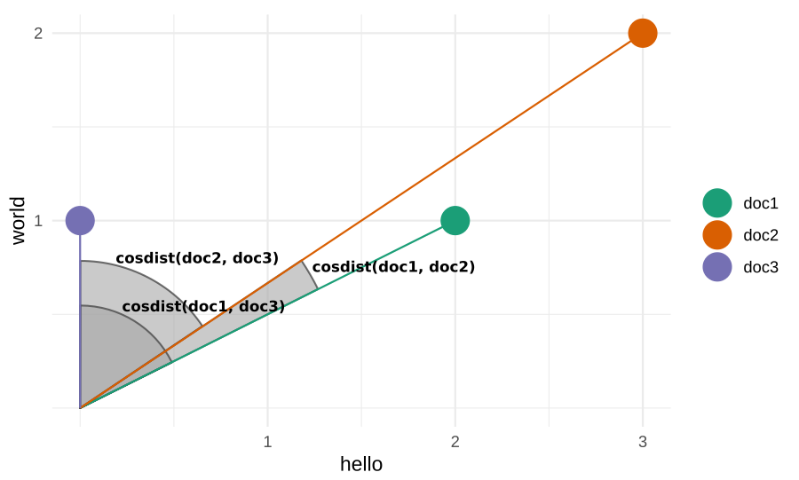

## Cosine distance

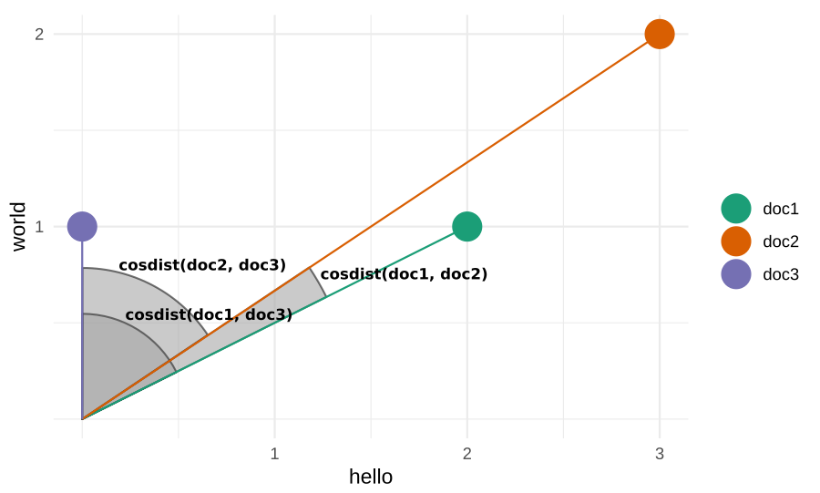

The angle \(\cos(\theta)\) between vectors \(x\), \(y\) can be calculated with:

\[ \cos(\theta) = \frac{x \cdot y}{\|x\| \|y\|} \] → calculate dot product of \(x\) and \(y\) and divide by product of their magnitudes (their "length").

## Cosine distance

Example in R for angle between *doc1* and *doc2*:

```r
doc1 <- docs['doc1',]
doc2 <- docs['doc2',]
cos_theta <- (doc1 %*% doc2) / (sqrt(sum(doc1^2)) * sqrt(sum(doc2^2)))
rad2deg(acos(cos_theta))   # cos^-1 (arc-cosine) converted to degrees
```

```
##          [,1]
## [1,] 7.125016
```

A function to calculate the cosine distance between \(n\)-dimensional feature vectors in a matrix `x`:

```r
cosineDist <- function(x) {
  cos_theta <- x %*% t(x) / (sqrt(rowSums(x^2) %*% t(rowSums(x^2))))
  as.dist(2 * acos(cos_theta) / pi)   # normalize to range [0, 1]
}
```

```r
cosineDist(docs)
```

```
##            doc1       doc2
## doc2 0.07916685
## doc3 0.70483276 0.62566592
```

## Cosine distance

**The cosine distance only takes the direction of the vectors into account, not their length.** This means it is invariant to scaling the vectors.

\[ x = \begin{pmatrix}2 \\ 1 \end{pmatrix},\\ y = \begin{pmatrix}4 \\ 2 \end{pmatrix} \]

What is the angle between these vectors?

It is 0 because \(y = 2x\). Both vectors point in the same direction, hence their angle is the same. Only their magnitude is different.

**In practical terms this means the cosine distance only takes word proportions into account.**

The cosine distance does not adhere to the second condition of distance metrics (*only* identical vectors have a distance of 0).

## Closing words on document similarity

For illustrative purposes, we've used vectors in 2D space, i.e. with only two words ("hello" and "world"). Most text corpora contain thousands of words. **Distances can be calculated in the same way in this \(n\)-dimensional space.**

There are much more distance metrics, but Euclidian and cosine distance are among the most popular.

Once you have a distance matrix, you can use it for **clustering documents**.

Remember that **we only compare word usage in documents**, not meaning, intent or sentiment. Two documents may have similar word usage but different meaning:

*doc1 = "not all cats are beautiful"*  
*doc2 = "all cats are not beautiful"*

## Literature

- [Feinerer et al 2008: Text Mining Infrastructure in R](https://www.jstatsoft.org/article/view/v025i05)
- Julia Silge, David Robinson 2018: Text mining with R – [available online for free](https://www.tidytextmining.com/)
- Kwartler 2017: Text Mining in Practice with R
- Ken Benoit, Paul Nulty (in progress): Quantitative Text Analysis Using R (with [quanteda package](https://quanteda.io/))

## Tasks

See dedicated tasks sheet on the [tutorial website](https://wzbsocialsciencecenter.github.io/wzb_r_tutorial/).